# West Coast Region Groundwater Level Conditions

The following provides an overview of groundwater (GW) conditions in the West Coast Region as of June 29, 2022.

This report was generated on June 29, 2022.

## Background

The province maintains a network of groundwater observation wells to monitor water levels in priority aquifers. These observation wells (OW) record water level fluctuations which allow for improved understanding of how aquifers respond to changes in climate, precipitation, and effects from pumping. Many of the observation wells are equipped with satellite telemetry to provide real time information on water levels.

The following summaries compare recent groundwater levels to all historical continuous daily records to determine percentile classes, with a minimum of 5 years of data. Historical monthly water level samples (before ~2004) are not included. A percentile is on a scale of 100 and indicates the percent of a distribution that is equal to or below it. For example, a groundwater level at the 10th percentile is equal to or greater than 10% of the water level values recorded on this day of the year during all previous years of data.

In general, a groundwater level value that is:

- the highest ever measured for the day of year is considered **High**
- greater than the 90th percentile is considered **Much Above Normal**
- between 75th percentile and 90th percentile is considered **Above Normal**
- between 25th and 75th percentiles is considered **Normal**
- less than the 25 percentile is considered **Below Normal**
- less than 10 percentile is considered **Much Below Normal**
- the lowest ever measured for the day of year is considered **Low**

## Groundwater Level Conditions

[interactive chart not shown]

**Note:** 🐟 = likely hydraulically connected

**Wells by Percentile Class**

|  | Current Year 2022-06-29 | Last Year 2021-06-29 |
| --- | --- | --- |
| High (100% - 100%) | 2 | 0 |
| Much Above Normal (90% - 100%) | 1 | 0 |
| Above Normal (75% - 90%) | 0 | 0 |
| Normal (25% - 75%) | 1 | 5 |
| Below Normal (10% - 25%) | 0 | 2 |
| Much Below Normal (0% - 10%) | 0 | 0 |
| Low (0% - 0%) | 0 | 1 |
| Across all classes | 4 | 8 |

## Wells Below Normal

This section reports on the number and total proportion of wells below normal or lower (i.e. 25th percentile or lower) on a given reporting date and one year prior for comparison. Hydraulic Connectivity and Aquifer Type categories are inferred based on aquifer subtype. Hydraulic connectivity is not field verified.

### All Wells

| Current Year 2022-06-29 | Last Year 2021-06-29 |
| --- | --- |
| 0% (0/4) | 38% (3/8) |

(X/Y) indicates X wells with low values out of Y wells total for that date

### By Hydraulic Connectivity

| Hydraulic connectivity | Current Year 2022-06-29 | Last Year 2021-06-29 |
| --- | --- | --- |
| Likely | 0% (0/4) | 38% (3/8) |
| Not Likely |  |  |
| Unknown |  |  |

(X/Y) indicates X wells with low values out of Y wells total for that date  
Blank cells indicate no data

### By Aquifer Type

| Aquifer Type | Current Year 2022-06-29 | Last Year 2021-06-29 |
| --- | --- | --- |
| Confined sand and gravel |  |  |
| Crystalline bedrock |  |  |
| Sedimentary |  |  |
| Unconfined sand and gravel | 0% (0/4) | 38% (3/8) |
| Unknown |  |  |

(X/Y) indicates X wells with low values out of Y wells total for that date  
Blank cells indicate no data

## Latest Details

**Latest details on observation wells in Water Year 2021 - 2022**

**Show/Hide**

| Location | Obs. Well | Hydraulic Connection | Aquifer Type | Latest Date | Percentile<sup>a</sup> | Remarks |
| --- | --- | --- | --- | --- | --- | --- |
| Alberni-Clayoquot Regional District |  |  |  |  |  |  |
| Ucluelet | OW329 | Likely | Unconfined sand and gravel | 2022-06-29** | Much Above Normal (94%) (n = 18) |  |
| Comox Valley Regional District |  |  |  |  |  |  |
| T'sable River | OW371 | Likely | Unconfined sand and gravel | 2022-05-05 | Not Available (n = 15) |  |
| Cowichan Valley Regional District |  |  |  |  |  |  |
| Chemainus | OW355 | Likely | Unconfined sand and gravel | 2022-06-29** | High (100%) (n = 17) |  |
| Duncan | OW204 | Likely | Unconfined sand and gravel | 2022-05-24 | Not Available (n = 19) |  |
| Duncan | OW211 | Likely | Unconfined sand and gravel | 2022-05-24** | Not Available (n = 17) |  |
| Mill Bay | OW470 | Likely | Unconfined sand and gravel | 2022-06-14 | Not Available (n = NA) |  |
| Regional District of Nanaimo |  |  |  |  |  |  |
| Cassidy | OW312 | Likely | Unconfined sand and gravel | 2021-09-14 | Not Available (n = 19) |  |
| Cassidy | OW437 | Likely | Unconfined sand and gravel | 2022-06-29** | High (100%) (n = 6) |  |
| Qualicum Beach | OW389 | Likely | Unconfined sand and gravel | 2022-06-29** | Normal (70%) (n = 10) |  |
| Strathcona Regional District |  |  |  |  |  |  |
| Quadra Island | OW383 | Likely | Unconfined sand and gravel | 2021-10-27 | Not Available (n = 13) |  |

<sup>a</sup> n is the number of years included in the percentile calculation.  
** Values with an Approval Status of ‘Working’

## Historical Water Level Plots

**Description**

Annual hydrographs and historical records for the observation wells summarized above can be found in this section.

Current conditions for provincial groundwater observation wells can be accessed any time through the [Groundwater Level Data Interactive Map](https://www2.gov.bc.ca/gov/content/environment/air-land-water/water/groundwater-wells-aquifers/groundwater-observation-well-network/groundwater-level-data-interactive-map).

Note: ‘Working’ data are preliminary and have not yet been finalized as ‘Approved’ data with approved corrections and data grades for quality assurance. Quality assurance procedures may result in differences between what is displayed as ‘Working’ and what will become the official record.

#### OW204 🐟

**Duncan (Duncan Rv Park North Boys Rd.)** | **Map**  
Unconfined sand and gravel aquifer | Likely hydraulically connected

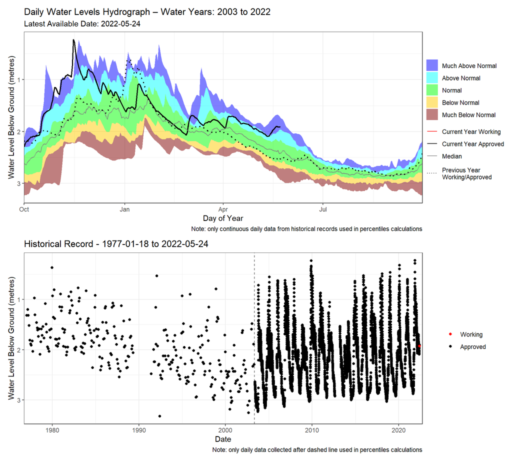

#### OW211 🐟

**Duncan (Marine Harvest Canada Boys Rd.)** | **Map**  
Unconfined sand and gravel aquifer | Likely hydraulically connected

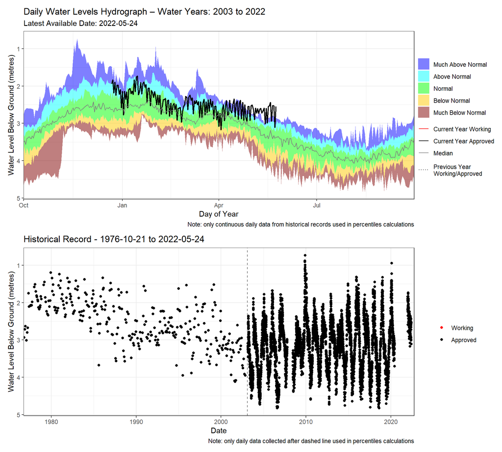

#### OW312 🐟

**Cassidy (Haslam Creek On T-Bridge Rd.)** | **Map**  
Unconfined sand and gravel aquifer | Likely hydraulically connected

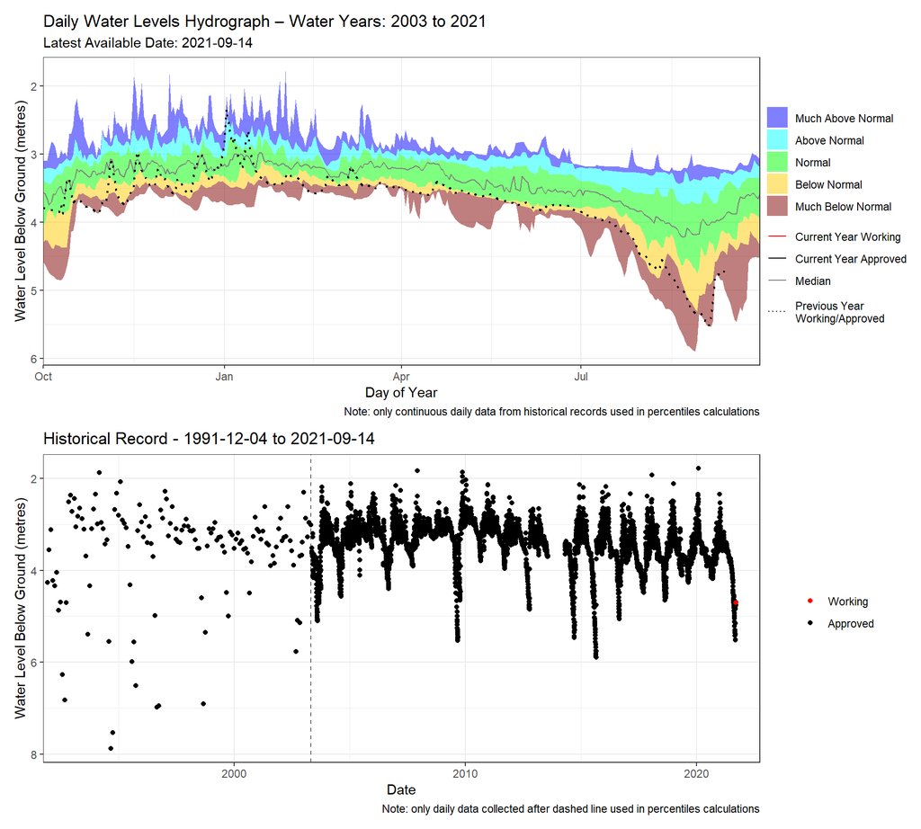

#### OW329 🐟

**Ucluelet (Hwys Yard)** | **Map**  
Unconfined sand and gravel aquifer | Likely hydraulically connected

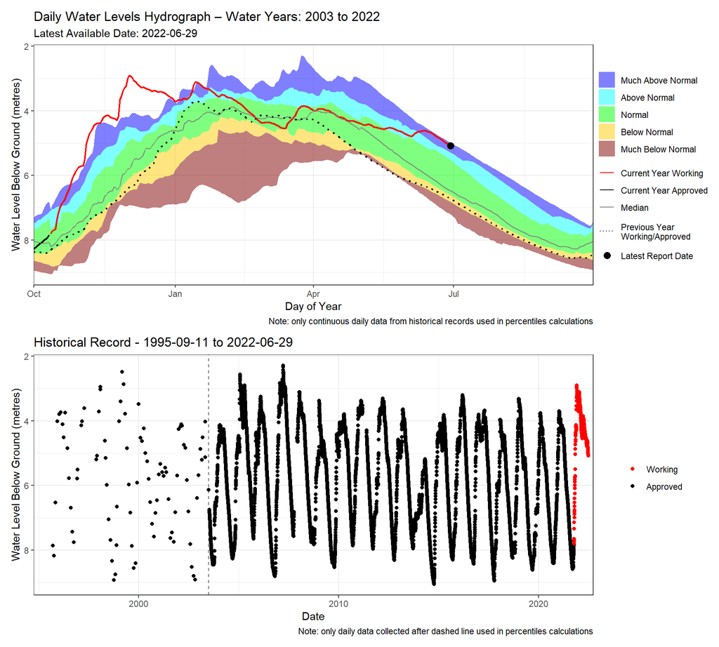

#### OW355 🐟

**Chemainus (Mt Sicker Rd.)** | **Map**  
Unconfined sand and gravel aquifer | Likely hydraulically connected

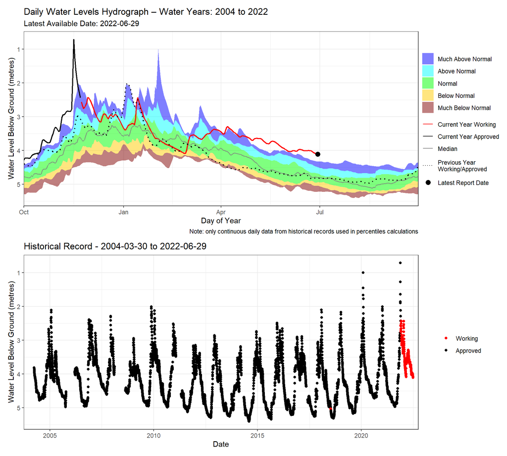

#### OW371 🐟

**T’sable River (Hwy 19a)** | **Map**  
Unconfined sand and gravel aquifer | Likely hydraulically connected

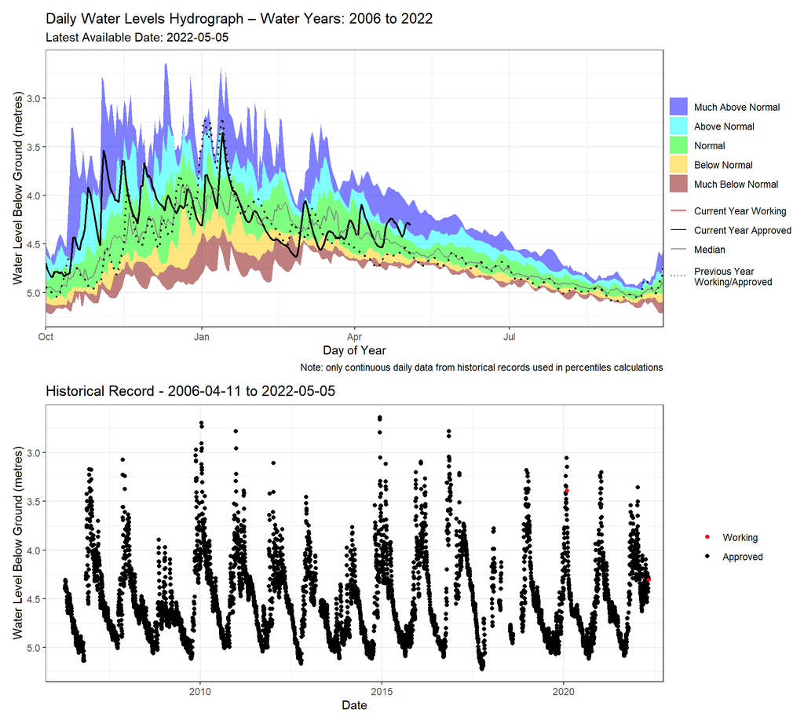

#### OW383 🐟

**Quadra Island (Heriot Bay Rd.)** | **Map**  
Unconfined sand and gravel aquifer | Likely hydraulically connected

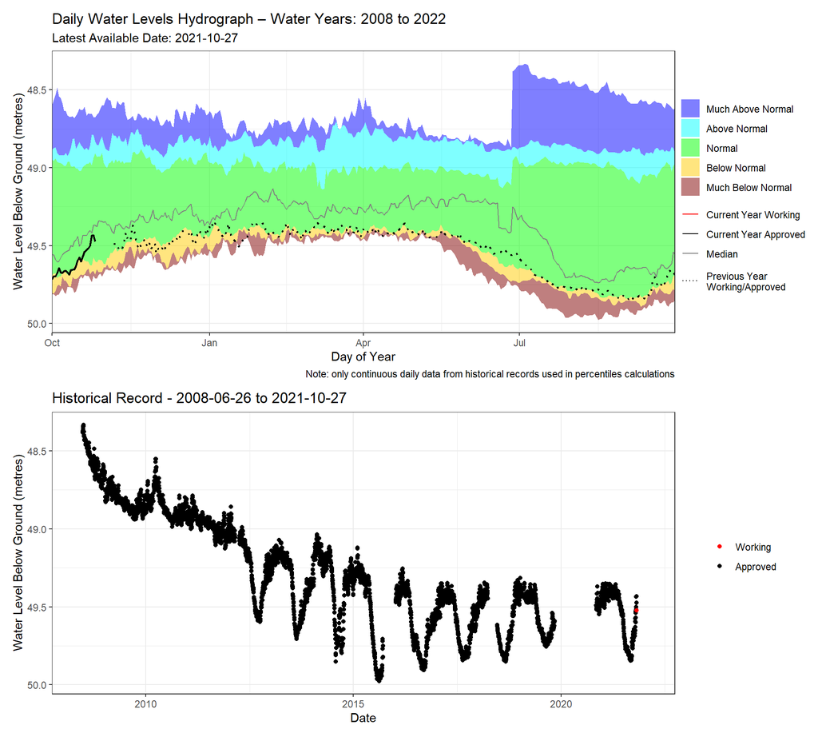

#### OW389 🐟

**Qualicum Beach (W. Island Hwy)** | **Map**  
Unconfined sand and gravel aquifer | Likely hydraulically connected

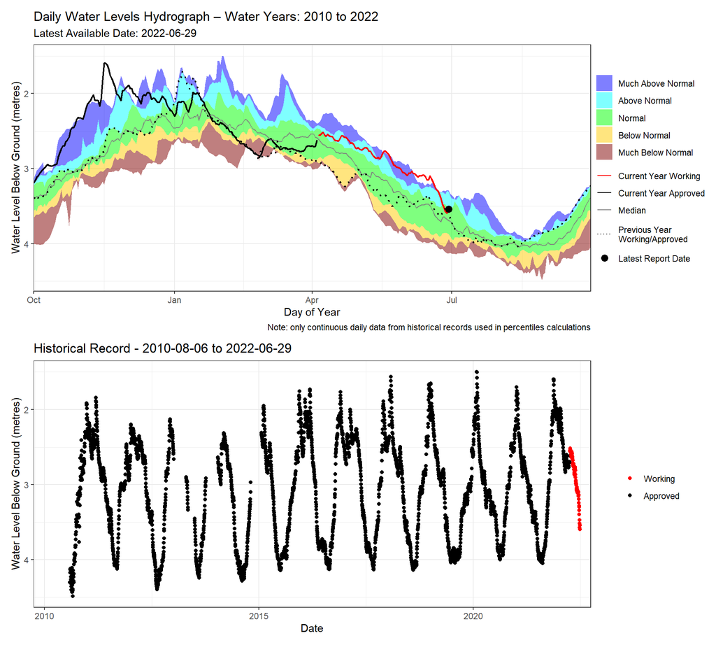

#### OW437 🐟

**Cassidy (Timberlands Rd. Shallow)** | **Map**  
Unconfined sand and gravel aquifer | Likely hydraulically connected

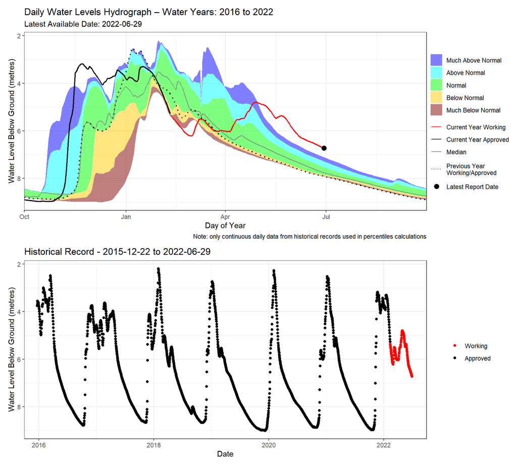

#### OW470 🐟

**Mill Bay (Deloume Rd)** | **Map**  
Unconfined sand and gravel aquifer | Likely hydraulically connected

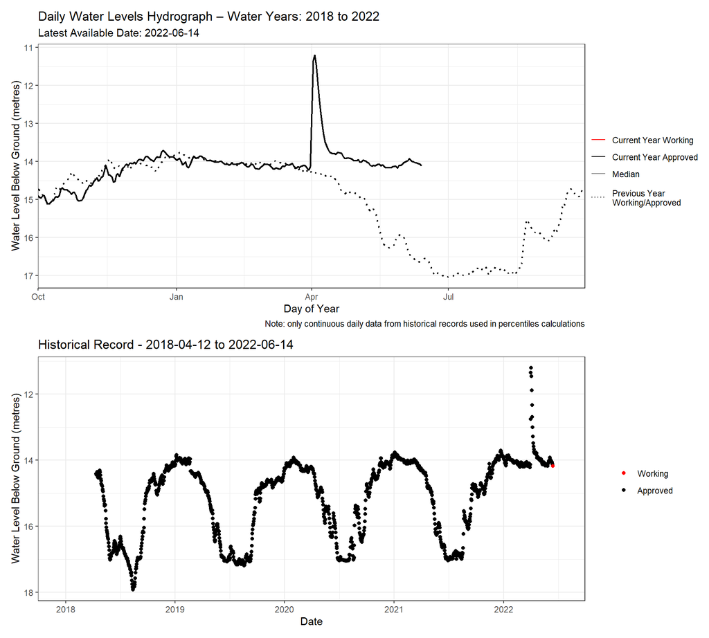

## Appendices

### A - Dates

If data isn’t available for an exact reporting date, dates up to 14 days before and 14 days after the report date are examined for non-missing data. Thus, an alternative date is chosen within a 29-day window, centred on the reporting date.

If there are multiple dates with data, the dates are ranked based on their historical data quality (for calculating percentiles) and their nearness to the original date indicated. The top date is then chosen for that well and that reporting date.

This table lists the original reporting dates, and the actual dates used for each observation well.

| Area | Location Name | Obs. Well | Report Dates vs. Measurement Dates 2022-06-29 | Report Dates vs. Measurement Dates 2021-06-29 |
| --- | --- | --- | --- | --- |
| West Coast Region |  |  |  |  |
| Alberni-Clayoquot Regional District | Ucluelet | OW329 | 2022-06-29 | 2021-06-29 |
| Comox Valley Regional District | T'sable River | OW371 | NA | 2021-06-29 |
| Cowichan Valley Regional District | Chemainus | OW355 | 2022-06-29 | 2021-06-29 |
| Cowichan Valley Regional District | Duncan | OW204 | NA | 2021-06-29 |
| Cowichan Valley Regional District | Duncan | OW211 | NA | 2021-06-29 |
| Cowichan Valley Regional District | Mill Bay | OW470 | NA | 2021-06-29 |
| Regional District of Nanaimo | Cassidy | OW312 | NA | 2021-06-29 |
| Regional District of Nanaimo | Cassidy | OW437 | 2022-06-29 | 2021-06-29 |
| Regional District of Nanaimo | Qualicum Beach | OW389 | 2022-06-29 | 2021-06-29 |
| Strathcona Regional District | Quadra Island | OW383 | NA | 2021-06-29 |

### B - Calculations

#### General details

- Water year starts in October
- Well measurements are all in Depth Below Ground in metres

#### Percentiles

- Percentiles are calculated individually for each day of the year for each well
- Percentiles are calculated only with “Approved” data
- 366th day in leap years is omitted
- “Good” quality data have ‘Approved’ historical values for >= 5 years
- “Poor” quality data have ‘Approved’ historical values for < 5 years and are not used (percentiles for that well on that day of the year are missing from the figures and tables).

### C - Run info

#### Parameters

- **Observation Wells** (`ows`): OW204, OW211, OW312, OW329, OW351, OW355, OW371, OW383, OW389, OW437, OW470
- **Report Dates** (`report_dates`): 2022-06-29, 2021-06-29
- **No. Days on either side of report date in which search for alternate date** (`n_days`): 14
- Total window around (and including) a reporting date is **29 days**
- **Percentile Calculations**
- **Min number of years** (`years_min`) - 5

#### Session Info

**Platform**

```
##  setting  value
##  version  R version 4.2.0 Patched (2022-05-30 r82437 ucrt)
##  os       Windows 10 x64 (build 19043)
##  system   x86_64, mingw32
##  ui       RStudio
##  language (EN)
##  collate  English_Canada.utf8
##  ctype    English_Canada.utf8
##  tz       America/Los_Angeles
##  date     2022-06-29
##  rstudio  2022.02.3+492 Prairie Trillium (desktop)
##  pandoc   2.17.1.1 @ C:/Program Files/RStudio/bin/quarto/bin/ (via rmarkdown)
```

**Packages**

[output not shown]

[output cut: 72 more lines]

[output not shown]